# Continua aprendiendo sobre EDA

Este es el fin de curso de Exploración de Datos, antes de hablar sobre como continuar aprendiendo, hablaremos sobre las conclusiones:

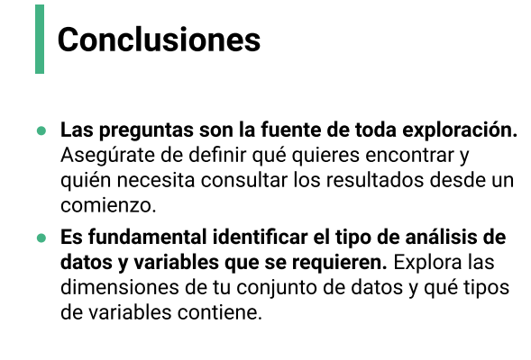

- Las preguntas son la fuente, así todo tendrá un inicio y un fin, así nosotros podremos saber que explicar y que resultados nos pueden arrojar esas preguntas. Es importante para tener acotado la obtención de la información.
- Hay que identificar que tipo de variables tenemos, si tenemos valores nulos y como se comportan las variables.

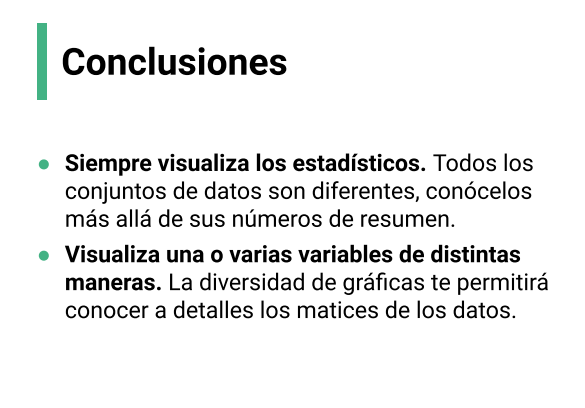

- Siempre visualiza los estadísticos, todos los conjuntos de datos son diferentes así que lo principal es conocerlos e ir más allá de un numero o resumen que me pueda entregar un parámetro estadístico. Recuerda el caso de la **paradoja de Simpson**, los números de manera aislada no tiene un significado y hasta nos podrían estar ocultando cierta información, sin embargo con el apoyo visual los números empiezan a tener sentido. Por eso simepre visualiza los estadísticos.
- Visualiza de distintas formas las variables: La diversidad de gráficas nos va a permitir entender y comprender los matices que existen en los datos. Darnos cuenta que si una relación parecería negativa, al incluir una nueva variable cambia completamente su comportamiento de la relación y cobra sentido, este tipo de situaciones suelen pasar a menudo, simplemente por no explorar el conjunto de datos de la manera correcta. Juega con las gráficas y preséntalas de diferentes formas hasta que sea clara la información que transmiten y que estamos encontrando, para asegurarnos que la exploración está avanzando

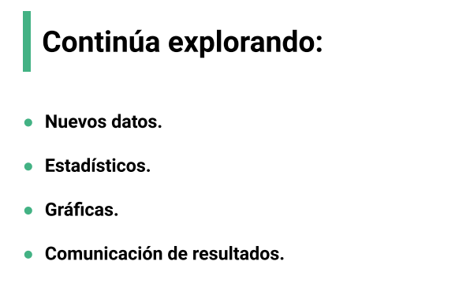

- Busca nuevos conjuntos de datos. Y replica el análisis o hazlo a tu propio modo que entiendas.
- Aprende nuevos temas estadísticos, entiende sus casos de uso para saber cuando aplicarlos en los datos y cuando no.
- Aprende sobre nuevas gráficas, nuevas formas de representar los resultados. Esto nos permitirá expandir ideas y no quedarnos cortos, además de ver los matices que pueden tener los conjuntos de datos.
- Continua aprendiendo como comunicar los resultados, ya sea a traves de un **notebook,dashboard**, como escribir en prosa lo que significa cada resultado hallado en los estadísticos. ¿Cómo podrías presentarlo a una persona que nunca ha visto tus datos?

## Extra:

Aporte Carlos Mazzaroli

Bueno gente, les tiro un trucazo, en un codigo corran este codigo

```
import palmerpenguins
import pandas as pd
import pandas_profiling as pp

df = palmerpenguins.load_penguins()

pp.ProfileReport(df)
```

Tira un reporte general de los datos bastante bueno para el principio del EDA

- [Librerías de Python para EDA](https://www.youtube.com/watch?v=shcDnxhP12c)